# Discrete Characters

Cleaning the data and visualizing it:

```r
devtools::install_github("bomeara/geiger")
library ("ape")
library ("corHMM")
library("geiger")
library("phangorn")

tree <- read.nexus(file = "floral_1.nex")
#To be able to work with a smaller dataset, I only copied the first 25 species from the binary data file.
discrete.data <- read.csv(file = "smalldata.csv", row.names = 1, stringsAsFactors = FALSE)

CleanData <- function(phy, data) {
  treedata(phy = phy, data = data, sort = TRUE)
}

##Testing the function
geo <- get(data("geospiza"))
CleanData(geo$phy, geo$dat)
```

```
## $phy
##
## Phylogenetic tree with 13 tips and 12 internal nodes.
##
## Tip labels:
##  fuliginosa, fortis, magnirostris, conirostris, scandens, difficilis, ...
##
## Rooted; includes branch lengths.
##
## $data
##                 wingL  tarsusL  culmenL    beakD   gonysW
## fuliginosa   4.132957 2.806514 2.094971 1.941157 1.845379
## fortis       4.244008 2.894717 2.407025 2.362658 2.221867
## magnirostris 4.404200 3.038950 2.724667 2.823767 2.675983
## conirostris  4.349867 2.984200 2.654400 2.513800 2.360167
## scandens     4.261222 2.929033 2.621789 2.144700 2.036944
## difficilis   4.224067 2.898917 2.277183 2.011100 1.929983
## pallida      4.265425 3.089450 2.430250 2.016350 1.949125
## parvulus     4.131600 2.973060 1.974420 1.873540 1.813340
## psittacula   4.235020 3.049120 2.259640 2.230040 2.073940
## pauper       4.232500 3.035900 2.187000 2.073400 1.962100
## Platyspiza   4.419686 3.270543 2.331471 2.347471 2.282443
## fusca        3.975393 2.936536 2.051843 1.191264 1.401186
## Pinaroloxias 4.188600 2.980200 2.311100 1.547500 1.630100
```

```r
cleaned_data <- CleanData(tree, discrete.data)
```

[output not shown]

[output cut: 327 more lines]

[output not shown]

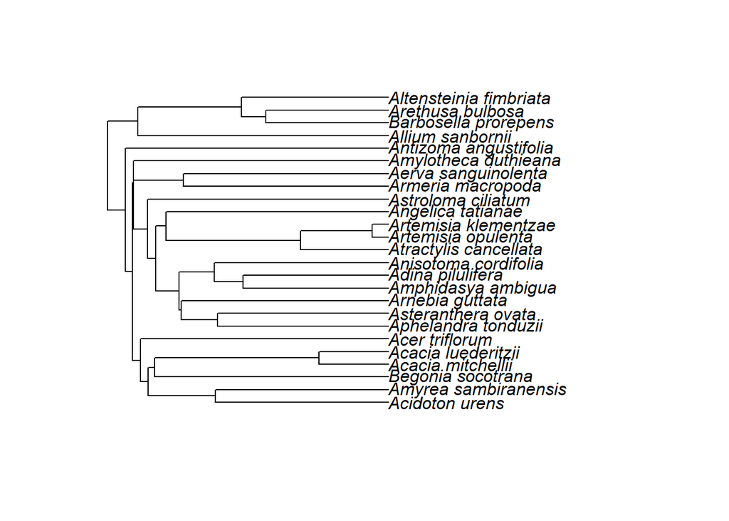

```
##                        Steb1Perianth Steb2PerFusSDS Steb3SymSDS
## Acidoton_urens                     1              0           0
## Amyrea_sambiranensis               1              0           0
## Begonia_socotrana                  0              0           0
## Acacia_mitchellii                  0              1           0
## Acacia_luederitzii                 0              1           0
## Acer_triflorum                     0              0           0
## Aphelandra_tonduzii                0              1           1
## Asteranthera_ovata                 0              1           1
## Arnebia_guttata                    0              1           0
## Amphidasya_ambigua                 0              1           0
## Adina_pilulifera                   0              1           0
## Anisotoma_cordifolia               0              1           0
## Atractylis_cancellata              0              1           1
## Artemisia_opulenta                 0              1           0
## Artemisia_klementzae               0              1           0
## Angelica_tatianae                  0              0           0
## Astroloma_ciliatum                 0              1           0
## Armeria_macropoda                  0              0           0
## Aerva_sanguinolenta                1              0           0
## Amylotheca_duthieana               0              1           0
## Antizoma_angustifolia              0              0           0
## Allium_sanbornii                   0              1           0
## Barbosella_prorepens               0              0           1
## Arethusa_bulbosa                   0              0           1
## Altensteinia_fimbriata             0              0           1
##                        Steb4StamNo Steb5Syncarpy Steb8Ovary
## Acidoton_urens                   0             1          1
## Amyrea_sambiranensis             0             1          0
## Begonia_socotrana                0             1          1
## Acacia_mitchellii                0             0          0
## Acacia_luederitzii               0             0          0
## Acer_triflorum                   1             1          0
## Aphelandra_tonduzii              1             1          0
## Asteranthera_ovata               1             1          0
## Arnebia_guttata                  1             1          0
## Amphidasya_ambigua               1             1          1
## Adina_pilulifera                 1             1          1
## Anisotoma_cordifolia             1             1          0
## Atractylis_cancellata            1             1          1
## Artemisia_opulenta               1             1          1
## Artemisia_klementzae             1             1          1
## Angelica_tatianae                1             1          1
## Astroloma_ciliatum               1             1          0
## Armeria_macropoda                1             1          0
## Aerva_sanguinolenta              1             1          0
## Amylotheca_duthieana             1             1          1
## Antizoma_angustifolia            1             0          0
## Allium_sanbornii                 1             1          0
## Barbosella_prorepens             1             1          1
## Arethusa_bulbosa                 1             1          1
## Altensteinia_fimbriata           1             1          1
## NULL
```

```r
VisualizeData <- function(phy, data){
  picture <- plot.phylo(x=phy)
  table <- print(x=data)
  together <- View(picture, table)
  print(together)
}
VisualizeData(phy=cleaned_data$phy, data = cleaned_data$data)
```

Next phases

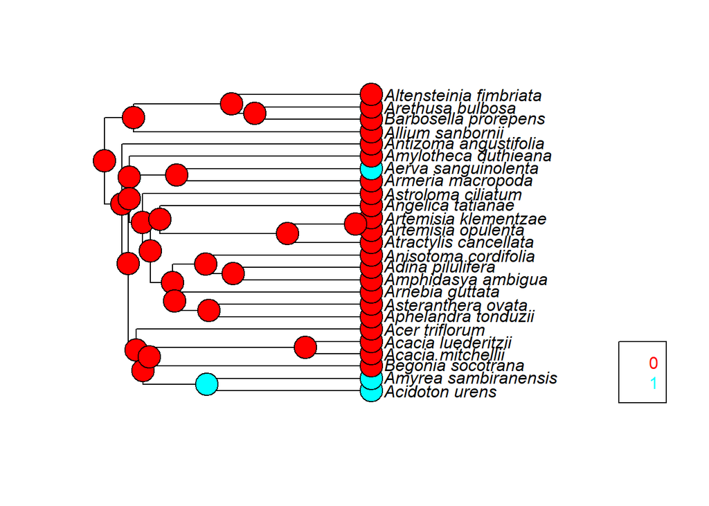

```r
cleaned.discrete.phyDat <- phangorn::phyDat(cleaned_data$data, type="USER", levels = c("0", "1")) #phyDat is a data format used by phangorn
anc.p <- phangorn::ancestral.pars(cleaned_data$phy, cleaned.discrete.phyDat)
plotAnc(cleaned_data$phy, anc.p)
```

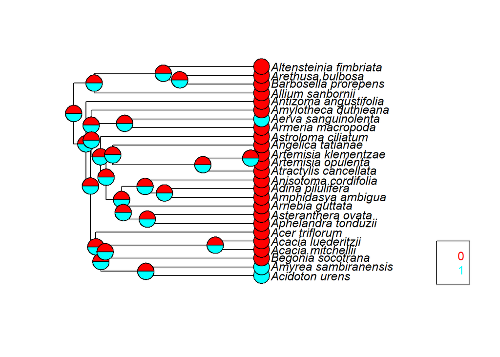

```r
anc.ml <- ancestral.pml(pml(cleaned_data$phy, cleaned.discrete.phyDat), type="ml")
plotAnc(cleaned_data$phy, anc.ml, 1)
```

The maximum likelihood plots differ from the parsimony plots in that the parsimony plots assume that the ancestral states were ones that had the least amount of changes to get to the current morphological state. Maximum likelihood gives equal probability to each state.

```r
#the function rayDISC needed the rownames in the matrix to be an actual column
library("data.table")
noname <- data.table(cleaned_data$data, keep.rownames = TRUE)
tr1 <- rayDISC(cleaned_data$phy, noname, model = "ARD", node.states = "marginal")
```

```
## State distribution in data:
## States:  0   1
## Counts:  22  3
## Initializing...
## Finished. Beginning thorough search...
## Finished. Inferring ancestral states using marginal reconstruction.
```

```r
tr2 <- rayDISC(cleaned_data$phy, noname, charnum = 2, model = "ARD", node.states = "marginal")
```

```
## State distribution in data:
## States:  0   1
## Counts:  11  14
## Initializing...
## Finished. Beginning thorough search...
## Finished. Inferring ancestral states using marginal reconstruction.
```

```r
tr3 <- rayDISC(cleaned_data$phy, noname, charnum = 3, model = "ARD", node.states = "marginal")
```

```
## State distribution in data:
## States:  0   1
## Counts:  19  6
## Initializing...
## Finished. Beginning thorough search...
## Finished. Inferring ancestral states using marginal reconstruction.
```

```r
tr4 <- rayDISC(cleaned_data$phy, noname, charnum = 4, model = "ARD", node.states = "marginal")
```

```
## State distribution in data:
## States:  0   1
## Counts:  5   20
## Initializing...
## Finished. Beginning thorough search...
## Finished. Inferring ancestral states using marginal reconstruction.
```

```r
tr5 <- rayDISC(cleaned_data$phy, noname, charnum = 5, model = "ARD", node.states = "marginal")
```

```
## State distribution in data:
## States:  0   1
## Counts:  3   22
## Initializing...
## Finished. Beginning thorough search...
## Finished. Inferring ancestral states using marginal reconstruction.
```

```r
tr6 <- rayDISC(cleaned_data$phy, noname, charnum = 6, model = "ARD", node.states = "marginal")
```

```
## State distribution in data:
## States:  0   1
## Counts:  13  12
## Initializing...
## Finished. Beginning thorough search...
## Finished. Inferring ancestral states using marginal reconstruction.
```

```r
tr1
```

```
##
## Fit
##       -lnL      AIC     AICc ntax
##  -8.432542 20.86508 21.41054   25
##
## Rates
##    0         1
## 0 NA 0.0010023
## 1  0        NA
##
## Arrived at a reliable solution
```

```r
tr2
```

```
##
## Fit
##       -lnL      AIC     AICc ntax
##  -13.93614 31.87227 32.41773   25
##
## Rates
##             0          1
## 0          NA 0.00431833
## 1 0.000536533         NA
##
## Arrived at a reliable solution
```

```r
tr3
```

```
##
## Fit
##       -lnL      AIC     AICc ntax
##  -12.19903 28.39806 28.94352   25
##
## Rates
##    0           1
## 0 NA 0.001711806
## 1  0          NA
##
## Arrived at a reliable solution
```

```r
tr4
```

```
##
## Fit
##       -lnL      AIC    AICc ntax
##  -7.919521 19.83904 20.3845   25
##
## Rates
##              0  1
## 0           NA  0
## 1 0.0005564867 NA
##
## Arrived at a reliable solution
```

```r
tr5
```

```
##
## Fit
##       -lnL      AIC     AICc ntax
##  -7.502135 19.00427 19.54972   25
##
## Rates
##              0  1
## 0           NA  0
## 1 0.0009130522 NA
##
## Arrived at a reliable solution
```

```r
tr6
```

```
##
## Fit
##       -lnL      AIC     AICc ntax
##  -16.05376 36.10752 36.65298   25
##
## Rates
##             0           1
## 0          NA 0.006661756
## 1 0.008077885          NA
##
## Arrived at a reliable solution
```

Questions:  
1) The outputs are for each of the 6 character traits that were present in the dataset.  
2) A T-test could be performed to see if the transition rate from 0 to 1 is the same as the rate from 1 to 0 for each of the character traits.  
3) All of the traits are variable, which introduces acquisition bias and can lead to overestimation in branch lengths.As long as this bias is accounted for, the MKV model could be used. In the details section of the lewisMkv function, it says it accounts for all of the traits being variable.

```r
mkv <- lewisMkv(phy = cleaned_data$phy, data = cleaned_data$data, include.gamma = TRUE)
```

```
## Getting starting branch lengths using a Rogers-Swoffordish approximation....
## Finished. Optimizing model parameters...
## Finished.
```

```r
mkv
```

```
## $np
## [1] 49
##
## $loglik
## [1] -50.88567
##
## $AIC
## [1] 199.7713
##
## $gamma.shape
## [1] 2.718282
##
## $phy
##
## Phylogenetic tree with 25 tips and 24 internal nodes.
##
## Tip labels:
##  Acidoton_urens, Amyrea_sambiranensis, Begonia_socotrana, Acacia_mitchellii, Acacia_luederitzii, Acer_triflorum, ...
##
## Rooted; includes branch lengths.
##
## $data
##                        Steb1Perianth Steb2PerFusSDS Steb3SymSDS
## Acidoton_urens                     1              0           0
## Amyrea_sambiranensis               1              0           0
## Begonia_socotrana                  0              0           0
## Acacia_mitchellii                  0              1           0
## Acacia_luederitzii                 0              1           0
## Acer_triflorum                     0              0           0
## Aphelandra_tonduzii                0              1           1
## Asteranthera_ovata                 0              1           1
## Arnebia_guttata                    0              1           0
## Amphidasya_ambigua                 0              1           0
## Adina_pilulifera                   0              1           0
## Anisotoma_cordifolia               0              1           0
## Atractylis_cancellata              0              1           1
## Artemisia_opulenta                 0              1           0
## Artemisia_klementzae               0              1           0
## Angelica_tatianae                  0              0           0
## Astroloma_ciliatum                 0              1           0
```

[output cut: 33 more lines]

```
## Altensteinia_fimbriata           1             1          1
##
## $opts
## $opts$algorithm
## [1] "NLOPT_LN_SBPLX"
##
## $opts$maxeval
## [1] "100000"
##
## $opts$ftol_rel
## [1] 0.0001220703
##
##
## attr(,"class")
## [1] "lewis.mkv"
```

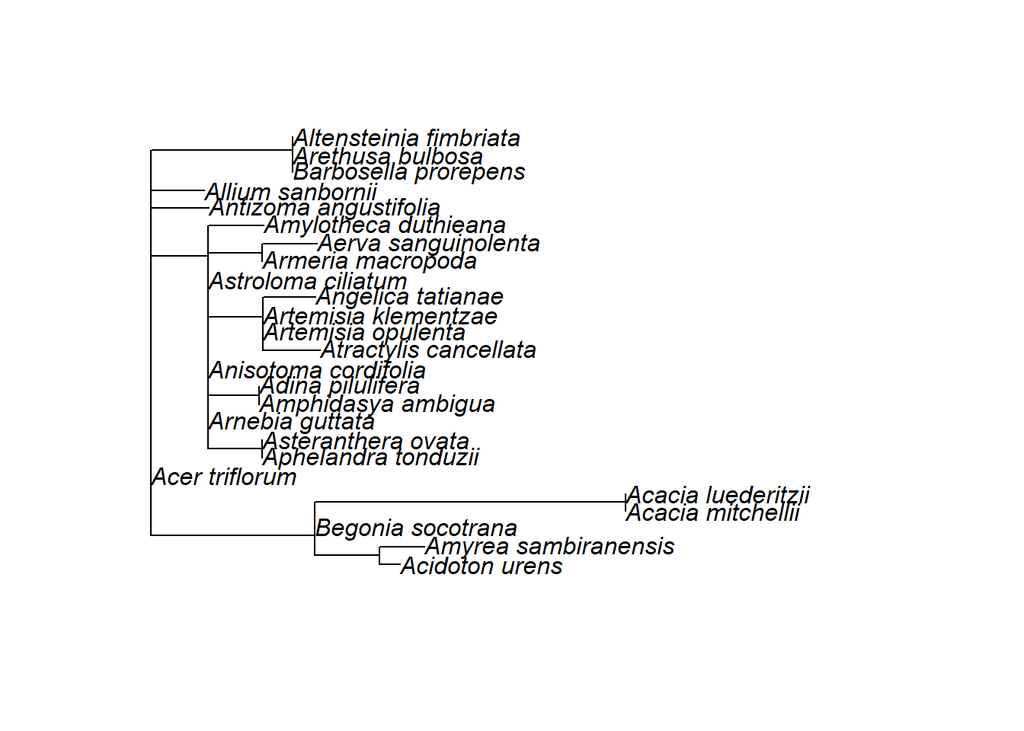

```r
plot(mkv$phy)
```

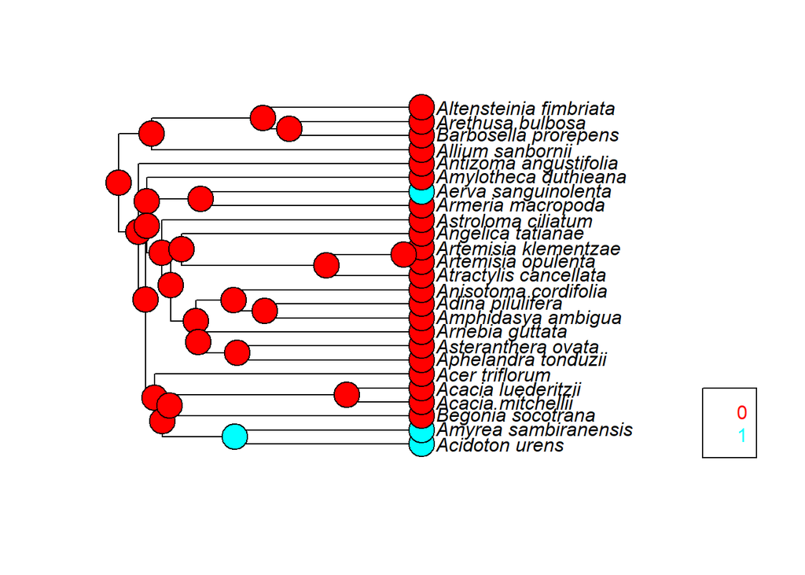

```r
plotAnc(cleaned_data$phy, anc.p)
```

The branch lengths obviously change, but the overall layout of the tree is basically the same. The MKV tree has a lot of polytomies as well.  
4) Since these characters are only binary, testing the state evolution is just seeing if the 0 or 1 state came first. This could be determined by looking at the probability of the ancestral state at the root. Which ever state is more likely there, is the one that came first.